# Laboratorio de física de partículas

## Geant4 powered with Docker

[figure not shown]

## Objetivo

Simular la interacción básica de partículas con ciertos medios gracias al software Geant4, desarrollado por el CERN.

## Play with Docker

Play with Docker es un servicio cloud que nos permite jugar con Docker sin necesidad de instalar Docker localmente. Cada vez que accedemos a una sesión en [Play with Docker](https://labs.play-with-docker.com/), tenemos 4 maravillosas horas para experimentar con Docker, hasta que esta se cierra automáticamente. Parece poco tiempo pero es el suficiente para llevar a cabo nuestro humilde y divertido laboratorio. Dicho de otra manera: tenemos acceso casi ilimitado (en recursos) a un super computador orientado a familiarizarnos con contenedores virtuales durante todo el periodo de duración de la clase/laboratorio. Para acceder a Play with Docker, sólo necesitamos una [cuenta en Docker](https://hub.docker.com/register/). Como en la gran mayoría de servicios, este registro es gratuito, rápido y comporta los típicos pasos de selección de contraseña, envío de correo, confirmación de recepción de correo, etc.

Una vez que ya tenemos acceso a la consola de Play with Docker, podemos solicitar máquinas reales (en realidad siguen siendo virtuales, pero a efectos prácticos, las trataremos como si fueran reales) sobre las que ejecutar a su vez contenedores Docker gracias a su [toolkit](https://docs.docker.com/engine/reference/commandline/docker/#child-commands). Al inicio no habrá ninguna, pero podemos crear la primera (y única que necesitamos) con el comando ADD NEW INSTANCE que se puede ver en la imagen.

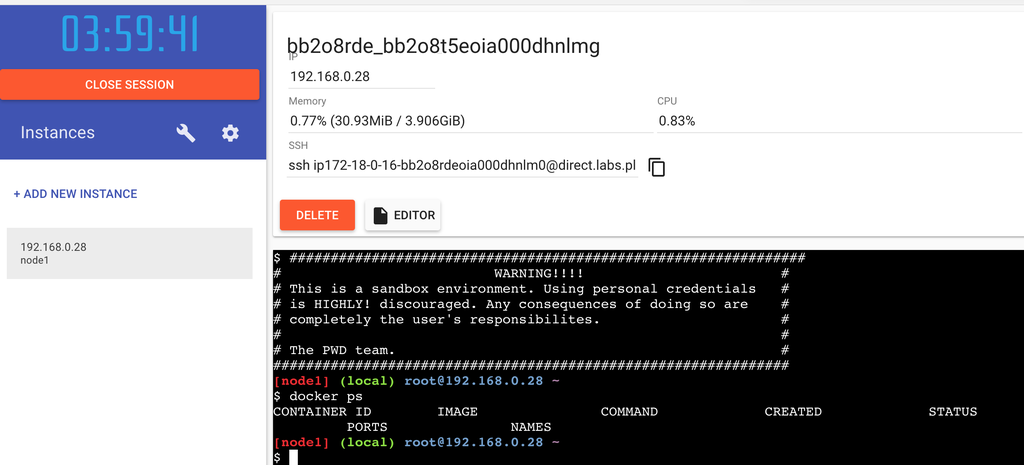

Cuando creamos una instancia, es como si accediéramos a una máquina pseudo real (o para lo que a todos los efectos, será una máquina real para nosotros). Se nos abrirá una sesión de shell de GNU Linux (Bash en este caso) justo al lado y sobre la que podemos introducir comandos Unix de toda la vida, entre ellos los relacionados con Docker. En estas máquinas cuasi-reales ya está instalado todo el stack de Docker y podemos, a su vez, trabajar con contenedores virtuales basados en esta tecnología de vanguardia. En realidad Play with Docker hace uso de [DIND](https://github.com/jpetazzo/dind). Esta tecnología permite albergar contenedores Docker dentro de un contenedor Docker (sí, algo así como un sueño dentro de un sueño). Es decir: las instancias en Play with Docker son en realidad… ¡contenedores Docker!

> Una máquina virtual es una visualización de un equipo físico completo. Se emula por software todos sus componentes, tanto físicos como lógico. Esto incluye los discos duros, tarjeta de red, gráfica, sonido, etc. Además del SO con su kernel y todos sus servicios.

Fíjate que la instancia que has creado en Play with Docker es como si se tratara de un ordenador tuyo que estuviera en red y en ese ordenador tuvieras instalado Docker. Así de sencillo. A partir de ese momento ya no necesitamos acceder a Play with Docker mediante en el navegador (aunque está bien que lo dejes aparcado a un lado en caso de necesidad). Usaremos VS Code y acceso SSH tradicional, concretamente mediante dos clientes SSH milenarios: [OpenSSH](https://www.openssh.com/) y [Putty](https://www.putty.org/). El primero viene preinstalado típicamente en máquinas GNU/Linux y macOS y el segundo se tiene que descargar y hay versiones para todos los sistemas operativos (es el que se recomienda, por simplicidad, si estás en Windows). Este enunciado viene preparado para uses cualquiera de los dos, en cualquier sistema.

Importante: tómate nota del usuario que te da Play with Docker y que empieza por `ip` y acaba en `@direct…` (Ejemplo: `ip172-18-0-27-bg3pvjs3uhdg008ir0fg`). Copia esa cadena de texto y guárdatela para futuros usos. A lo largo de este trabajo nos referiremos a ella con la variable de entorno `$usuariopwd`. También puedes regenerar el contenido de esta variable mediante este comando (a ejecutar en la consola web de Play with Docker):

```
echo ip$(ifconfig eth1 | grep "inet " | awk -F'[: ]+' '{ print $4 }' | sed 's/\./-/g')-$SESSION_ID
```

### Pregunta: ¿qué hace el comando anterior? ¿De qué subcomandos se compone y qué papel juegan (ifconfig, grep, awk y sed)?

> Ejecuta el comando `echo` que imprime por la salida estándar el texto que le siga, expandiendo el contenido de las variables. En nuestro caso tenemos dos variables, una de ellas implícita. El formato que tenemos es este `echo ip$var1-$var2`. Donde `$var1` representa el resultado de la expresión contenida entre paréntesis y `$var2` representa el contenido de la variable `$SESSION_ID`, que no es otro que el identificador de sesión que nos ha asignado `Play whit Docker`.

> Para lo que sería `$var1`, dentro del paréntesis se ejecuta el comando `ifconfig eth1` y su salida la pasa al comando `grep "inet "` usando una tubería (pipe), este pasa su salida a `awk -F'[: ]+' '{ print $4 }'` y este a `sed 's/\./-/g'`.
> - **ifconfig:** El comando `ifconfig` muestra las propiedades de las interfaces de red instaladas en el equipo. El argumento `eth1` filtra la salida para que solo devuelva las propiedades de la interfaz de red con ese nombre.

>   Ejemplo de salida del comando `ifconfig eth0`

>   ```
>   jose@Aurora-R6:/mnt/c/Users/joseh$ ifconfig eth0
>   eth0: flags=4163<UP,BROADCAST,RUNNING,MULTICAST>  mtu 1500
>           inet 172.23.122.172  netmask 255.255.240.0  broadcast 172.23.127.255
>           inet6 fe80::215:5dff:fe1b:172d  prefixlen 64  scopeid 0x20<link>
>           ether 00:15:5d:1b:17:2d  txqueuelen 1000  (Ethernet)
>           RX packets 23126  bytes 6106428 (5.8 MiB)
>           RX errors 0  dropped 0  overruns 0  frame 0
>           TX packets 19  bytes 1426 (1.3 KiB)
>           TX errors 0  dropped 0 overruns 0  carrier 0  collisions 0
>   ```

>   Nótese que he cambiado el argumento `eth1` por `eth0`, puesto que mi maquina no dispone de una interfaz de red con el nombre `eth1`.
> - **grep:** El comando `grep` busca un fragmento de texto y filtra cualquier contenido entre retornos de carro, y/o cambios de línea, que no contengan el fragmento de texto pasado como argumento. En nuestro caso todas las líneas que devuelva el comando `ifconfig eth0` que no contengan la cadena de caracteres `"inet "` incluyendo el espacio. Para nuestro ejemplo el comando `ifconfig eth0 | grep "inet "` devolvería lo siguiente:

>   ```
>   jose@Aurora-R6:/mnt/c/Users/joseh$ ifconfig eth0 | grep "inet "
>           inet 172.23.122.172  netmask 255.255.240.0  broadcast 172.23.127.255
>   ```

>   Como se ve, se han eliminado todas las líneas que no contenían el texto `"inet "`
> - **awk:** El comando `awk` al igual que `grep` busca un fragmento de texto, pero este puede filtrar el contenido de cada línea. En nuestro caso se establece el modo de funcionar usando varios argumentos. En `awk -F'[: ]+' '{ print $4 }'`, `-F'[: ]+'` establece la secuencia de caracteres que se usará como separador de campos, `-F` indica que se va a establecer un separador de campos especifico. Lo que le sigue es una expresión regular, o *regex*, con la que desea que coincida el texto que hará de separador de campos. Concretamente `-F'[: ]+'` establece como separador de campos cualquier secuencia que este compuesta de uno o más caracteres de los contenidos entre los corchetes, estos son los dos puntos ':' y el espacio. Todos estos ejemplos coincidirían con ese regex `' :: '`, `' '`, `'::::::::'`. La parte `'{ print $4 }'` expresa como formatear la salida, en este ejemplo se establece que se imprima el cuarto campo, es decir el contenido entre la tercera y la cuarta coincidencia del regex.

>   En mi ejemplo nos encontramos un problema, este es que el comando anterior devuelve la línea con espacios antes de la cadena `"inet "`, por lo que el primer campo corresponde al contenido antes de la primera coincidencia del regex, que evidentemente es una cadena vacía `''`. Esto provoca que no se devuelva lo que se espera, si no que devuelve `netmask`.

>   ```
>   jose@Aurora-R6:/mnt/c/Users/joseh$ ifconfig eth0 | grep "inet " | awk -F'[: ]+' '{ print $4 }'
>   netmask
>   ```

>   Para conseguir que se devuelva mi mascara de red se debería de usar `awk -F'[: ]+' '{ print $5 }'`:

>   Pero intuyo que lo que se desea es mi dirección IP, para lo cual necesitaremos usar `awk -F'[: ]+' '{ print $3 }'`

> - **sed:** El comando `sed` permite modificar el texto que recibe. En tal como está configurado con `'s/\./-/g'`, se le está pidiendo que sustituya cada punto `.` que encuentre por un guion `-`.

>   En el ejemplo resultaría:

>   ```
>   jose@Aurora-R6:/mnt/c/Users/joseh$ ifconfig eth0 | grep "inet " | awk -F'[: ]+' '{ print $3 }' | sed 's/\./-/g'
>   172-23-122-172
>   ```

>   Con esto tenemos el contenido del paréntesis, a lo que le precede los caracteres 'ip' y le sigue un guion seguido del contenido de la variable `$SESSION_ID` que para el enunciado contiene `bg3pvjs3uhdg008ir0fg`. Así que el comando `echo` mostrará primero la parte explicita `ip`, seguido de lo del paréntesis `172-23-122-172`, seguido de un guion `-` explícito y finalmente la variable $SESSION_ID `bg3pvjs3uhdg008ir0fg`. Si lo juntamos el resultado es:

>   ```
>   ip172-23-122-172-bg3pvjs3uhdg008ir0fg
>   ```

>   Como vemos coincide con lo mencionado `ip172-18-0-27-bg3pvjs3uhdg008ir0fg`, con la salvedad de que la ip que aparece es la de mi máquina.

## Software a instalar localmente

Estos son los distintos programas/paquetes que necesitas en tu sistema local:

- [Visual Studio Code](https://code.visualstudio.com/) (VS Code, para los amigos).
- [Python](https://marketplace.visualstudio.com/items?itemName=ms-python.python). ¡Ojo!, no es necesario instalar Python ni vamos a trabajar con un intérprete de este lenguaje en nuestra máquina local. Sólo queremos esta extensión para que VS Code haga sintaxis de color de código Python (que será ejecutado por un contenedor Docker que crearemos en nuestra instancia pseudoreal en el servicio Play with Docker).
- [Preview on Web Server](https://github.com/YuichiNukiyama/vscode-preview-server), de Yuichi Nuikiyama. Esta extensión nos permite visualizar las simulaciones 3D en un navegador. Con la combinación de teclas Cntrl + Shift + L se abrirá un navegador que estará atento a cambios en la página web donde se dibujen las escenas 3D representando la física que estamos simulando.
- [Putty](https://www.chiark.greenend.org.uk/~sgtatham/putty/latest.html), un cliente SSH muy conocido en Windows. También puedes usar Putty en macOS. Te recomiendo que los instales mediante [Scoop](https://scoop.sh/) o [Homebrew](https://brew.sh/), respectivamente.
- [Instant Player](http://www.instantreality.org/downloads) para visualizar las trazas de partículas. Se trata un visor de instrucciones [VWRL](https://en.wikipedia.org/wiki/VRML) disponible tanto para [macOS](http://doc.instantreality.org/media/uploads/downloads/2.8.0/InstantPlayer-MacOS-10.10-x64-2.8.0.38619.dmg), [Windows](http://doc.instantreality.org/media/uploads/downloads/2.8.0/InstantReality-Windows-vs2013-x64-2.8.0.38619.msi), [Ubuntu](http://doc.instantreality.org/media/uploads/downloads/2.8.0/InstantReality-Ubuntu-14.04-x64-2.8.0.38619.deb), [Red Hat](http://doc.instantreality.org/media/uploads/downloads/2.8.0/InstantReality-RedHat-7-x64-2.8.0.38619.rpm) y [SUSE](http://doc.instantreality.org/media/uploads/downloads/2.8.0/InstantReality-SLES-12.1-x64-2.8.0.38937.rpm). Para solucionar el problema de que falta un archivo `MSVCP110.dll` en el caso de algunas versiones de Windows, instalad el runtime mínimo de Microsoft Visual C++ 2012 Redistributable para 64 bit desde [aquí](http://www.microsoft.com/en-au/download/confirmation.aspx?id=30679).

### Preguntas

**¿Qué otros formatos estándar de representación 3D conoces (Collada, Stanford, Wavefront, X3D Extensible, Standard Tessellation Language, x3dom, etc.)?**

> Sinceramente, hasta antes de esto ninguno, salvo CAD, que en realidad no es un formato estándar, ya que CAD admite diferentes formatos, tanto para 2D como para 3D. Después de esto conozco los aquí mencionados. Collada, Stanford, Wavefront, X3D Extensible, Standard Tessellation Language, x3dom

**¿Quién desarrolla Instant Player qué contribuciones ha hecho al mundo de la tecnología?**

> Instant Player pertenece a 'The instantReality framework'. El proyecto está actualmente coordinado y respaldado por el grupo Fraunhofer IGD / [Visual Computing System Technologies](http://www.igd.fraunhofer.de/vcst/).

> [El Instituto Fraunhofer de Gráficos por Computadora (IGD-VCST)](http://www.igd.fraunhofer.de/vcst/) cubre un amplio espectro de experiencias y competencias en los campos de las tecnologías de Realidad Virtual / Aumentada y Computación Visual.
- [ParaView](http://www.paraview.org/), de [Kitware](https://www.kitware.com/), pero sólo se recomienda su uso en el caso de que, por alguna razón Instant Player no funcione de ninguna manera (quizás en el caso de que tu arquitectura sea todavía 32 bit). Para ver las trazas de las partículas correctamente, elige el modo Wireframe (barra de herramientas).

### Pregunta

**¿en qué proyectos está involucrada la fundación Kitware y cómo han cambiado el mundo de la informática, la tecnología, la ciencia y la medicina? Pista: CMake, VTK, ITK, etc.**

> - **The Visualization Toolkit (VTK)** es un sistema de software para gráficos 3D por ordenador, procesamiento de imágenes y visualización. Admite muchos algoritmos de visualización y técnicas de modelado. VTK puede realizar un procesamiento paralelo y puede representar datos científicos en un navegador web . VTK se utiliza en todo el mundo en aplicaciones comerciales, así como en investigación y desarrollo. Las aplicaciones que usan VTK incluyen Molekel, ParaView, VisIt, VisTrails, MOOSE, 3D Slicer, MayaVi y OsiriX. VTK está escrito en C ++ y está empaquetado para acceder a través de Python, Java y Tcl. ActiViz proporciona soporte para VTK en proyectos .Net / C #.
> - **ParaView** crea visualizaciones científicas interactivas para analizar datos utilizando técnicas cualitativas y cuantitativas. Tiene una arquitectura cliente-servidor para facilitar la visualización remota de conjuntos de datos y genera modelos de nivel de detalle (LOD) para mantener velocidades de cuadro interactivas para grandes conjuntos de datos. Está diseñado para el paralelismo de datos en multicomputadoras y clústeres de memoria compartida o memoria distribuida. También se puede ejecutar como una aplicación para una sola computadora.
> - **CMake** es una herramienta de compilación multiplataforma para controlar el proceso de compilación de software utilizando archivos de configuración simples independientes de la plataforma y del compilador. CMake genera archivos MAKE y espacios de trabajo nativos que se pueden usar en el compilador de su elección.
> - **The Insight Toolkit (ITK)** Es una biblioteca de algoritmos de segmentación y registro de imágenes adaptados para investigaciones médicas.

>   El kit de herramientas es compatible con una variedad de formatos de datos de imágenes, que incluyen imágenes digitales y comunicaciones en medicina (DICOM), MRI, CT y ultrasonido. Además, presenta un proceso de empaquetado automatizado para generar interfaces entre C++ y lenguajes de programación interpretados como Python o JavaScript, para permitir a los desarrolladores crear software usando una gran variedad de lenguajes de programación. Tiene una estructura modular flexible que es fácil de ampliar e integrar en varios proyectos.
> - **3D Slicer** es una aplicación de código abierto extensible para visualización y análisis de imágenes médicas. 3D Slicer funciona con imágenes ópticas, resonancia magnética, tomografía computarizada y datos de ultrasonido. Se ha utilizado para aplicaciones comerciales y de investigación que van desde estudios preclínicos en animales, hasta planificación y orientación quirúrgica, análisis de imágenes de ultrasonido, control de robots médicos y estudios de población.

>   3D Slicer utiliza VTK e ITK: VTK para sus procesos de renderizado 2D y 3D, transformación lineal y no lineal, infraestructura de segmentación, procesamiento de malla e integración de realidad virtual e ITK para el procesamiento de imágenes más lectura y escritura de imágenes.
> - **VIAME** es una plataforma de software de visión por computadora de código abierto diseñada para la inteligencia artificial (IA) *do-it-yourself* (hazlo tu mismo). Es un conjunto de herramientas en evolución que contiene muchos flujos de trabajo que se utilizan para generar diferentes detectores de objetos, clasificadores de fotograma completo, mosaicos de imágenes, generación rápida de modelos, búsqueda de imágenes y videos y métodos de medición estéreo.

> Originalmente dirigido al análisis de especies marinas, ahora contiene muchos algoritmos y bibliotecas comunes, y también es útil como una biblioteca genérica de visión por computadora fuera de las imágenes y videos submarinos. VIAME está disponible como aplicación web o de escritorio.
> - **TeleSculptor** es una aplicación de escritorio de usuario final de código abierto para fotogrametría aérea. Aprovecha los algoritmos de KWIVER para construir modelos de escenas en 3D a partir de videos aéreos, como videos recopilados de UAV. Maneja coordenadas geoespaciales y puede hacer uso de metadatos, si están disponibles, de sensores GPS e IMU. Sin embargo, también puede funcionar con datos no geoespaciales y con colecciones de imágenes sin metadatos asociados. Aunque es principalmente una aplicación de usuario final, es altamente reconfigurable para soportar también la investigación y el desarrollo de fotogrametría.
> - **Girder** es una plataforma de gestión de datos basada en web gratuita y de código abierto que forma parte del ecosistema de análisis y datos de Resonant. Puede usarse como una aplicación independiente o una plataforma para crear nuevos servicios web. Permite la construcción rápida y sencilla de aplicaciones web que tienen algunos o todos los siguientes requisitos: organización y difusión de datos, gestión y autenticación de usuarios, gestión de autorizaciones.
- [view3dscene](https://castle-engine.io/view3dscene.php), de [Castle Game Engine](https://castle-engine.io/index.php). Es otro visualizador 3D multiplataforma, parte de este conocidísimo motor de videojuegos (competencia directa de [Unity](https://unity.com/)).
- [Docker](https://www.docker.com/) ¡No! No es necesario instalar Docker, pero ya que estamos…

### Preguntas

**¿qué es Docker?**

**¿Qué son los contenedores virtuales?**

> La idea detrás de Docker es crear contenedores ligeros y portables para las aplicaciones software que puedan ejecutarse en cualquier máquina con Docker instalado, independientemente del sistema operativo que la máquina tenga por debajo, facilitando así también los despliegues. Es un entorno de virtualización ligero que te permite construir y ejecutar aplicaciones dentro de un contenedor de software aislado. No se apoya en un hypervisor como la virtualización tradicional, se puede considerar una aplicación dentro del servidor.

**¿Qué alternativas a Docker existen (OpenVZ, LXC, Vagrant, rkt, Singularity, etc.)?**

> Algunas de las alternativas que podemos encontrar son:
> - RKT.
> - PodMan.
> - Singularity.
> - Linux Containers – LXC.
> - OpenVz.

**Resume brevemente la historia de Docker.**

> [Docker](https://www.docker.com/) nace como un sistema enfocado a **Plataforma como Servicio**, o, **PaaS** de sus siglas en ingles *Platform as a Service*). **Solomon Hykes**, junto con otros ingenieros como **Andrea Luzzardi**, **Francois-Xavier Bourlet** y **Jeff Lindsay**, comenzó Docker como un proyecto interno dentro de la empresa **dotCloud**.

> Docker fue liberado en marzo de 2013 convirtiéndose en un software de código abierto.

> En el 2014 remplazó su entorno de ejecución por defecto por su propia biblioteca, libcontainer, escrita en **Go**.

> En abril de 2015, el proyecto tenía más de **20.700 estrellas de GitHub** (Posicionándolo en el **puesto 20ª** del rancking de proyectos con más estrellas de GitHub), más de 4.700 bifurcaciones (forks), y casi 900 colaboradores.

> En 2018 un estudio mostró que organizaciones como **Red Hat**, **Microsoft**, **IBM**, **Google**, **Cisco Systems** y **Amadeus IT Group**, aportaban mayores contribuciones al proyecto que el propio equipo de Docker, siendo **Red Hat** la organización más volcada con el proyecto.
- [PowerShell](https://docs.microsoft.com/en-us/powershell/). En el caso de Windows (en incluso [Linux](https://docs.microsoft.com/en-us/powershell/scripting/install/installing-powershell-core-on-linux?view=powershell-6) y [macOS](https://docs.microsoft.com/en-us/powershell/scripting/install/installing-powershell-core-on-macos?view=powershell-6)), te recomiendo que uses PowerShell. Se trata de un shell de código abierto y multiplataforma creado por Microsoft. Todos los comandos de este manual vienen preparados para Bash y PowerShell. VS Code debería detectar que tienes PowerShell instalado y ofrecerte su uso como shell por defecto, pero si acaso no fuera así, consulta esta [página de ayuda](https://techcommunity.microsoft.com/t5/itops-talk-blog/configure-visual-studio-code-to-run-powershell-for-windows-and/ba-p/283258) de Microsoft.

## Ejecución del laboratorio

La realización de este actividad se ha realizado ejecutando la simulación en un contenedor Docker en local, cortesía del Dr. Alberto Corbi.

- Lo primero es tener Docker instalado.
- En mi caso no necesitaremos necesitariamos los archivos `.key` y `.ppk` que contienen las claves que se utilizan en una comunicacion encriptada con cifrado de clave publica. Por lo que no necesitamos crear una instancia en Play with Docker.
- Abrimos una carpeta de trabajo (workspace) desde Visual Studio Code. En mi caso en un Subsistema de Windows para Linux (WLS2).
- Tampoco necesitamos sdscárgar los archivos `geant4lab.ppk` y `geant4lab.key` desde [aquí](https://github.com/pammacdotnet/FFRepo/raw/master/ppkkey.zip).

### Preguntas

**¿Qué es un fichero ppk?**

> Como he comentado mas arriba estos archivos contien las claves necesarias para encriptar y desemcriptar la informacion que se envia y se recive. Concretamente ppk contieen la clave privada y su nombre viene de **PuTTY Private Key**.

**¿Qué es una clave RSA público/privada (fichero key)?**

> Es el equivalente al ppk pero para usarlo en SSH en vez de PuTTY

## Descarga de la imagen Docker del laboratorio

Lo primero que tenemos que hacer es descargarnos la imagen de la pila de contenedores que conforman una imagen con todo lo necesario para ejecutar Geant4. Esta imagen [se encuentra ya en el Docker Hub](https://cloud.docker.com/u/pammacdotnet/repository/docker/pammacdotnet/geant4lab).

### Preguntas

**¿qué es el [Hub](https://hub.docker.com/) de Docker?**

> Docker Hub es un servicio proporcionado por Docker para encontrar y compartir imágenes de contenedores en nuestros ordenadores.

**¿Cuál es la diferencia entre una imagen y un contenedor?**

> Una imagen es una plantilla para construir un contenedor. Una imagen nunca cambia. Un contenedor es una instancia de una imagen. Se pueden costruir los contenedores que se quiera partiendo de la misma imagen.

Para descargar la imagen Docker con la que ejecutaremos la simulación, enviaremos el comando (`docker pull`) desde nuestra máquina local y esperamos a que se descargue.

Este comando Docker (`docker pull`) lo que hace es descargarse la imagen `geant4lab` del usuario `pammacdotnet` alojada en el [Hub de Docker](http://hub.docker.com/). La descarga se produce desde este *Hub* al disco de nuestra máquina local.

```
jose@Aurora-R6:~/FFI$ docker pull pammacdotnet/geant4lab
Using default tag: latest
latest: Pulling from pammacdotnet/geant4lab
32802c0cfa4d: Pulling fs layer
da1315cffa03: Pulling fs layer
fa83472a3562: Pulling fs layer
f85999a86bef: Pulling fs layer
4adeade91205: Pulling fs layer
a8e4b753ce11: Pulling fs layer
e9f91fadad2e: Pulling fs layer
05bd8563d519: Pulling fs layer
17dea6add1aa: Pulling fs layer
ffc09338d88e: Pulling fs layer
c7061889ec78: Pulling fs layer
82cf27079d06: Pull complete
3fd0b7114b4d: Pull complete
762fc1ce02fe: Pull complete
e29f76d111d5: Pull complete
10d5c3407cc3: Pull complete
cacafc401cf0: Pull complete
2e5ea4f36bbd: Pull complete
9a46be81e6b4: Pull complete
dd1b29d9ca12: Pull complete
b3d7bb7e2722: Pull complete
485e80a4790d: Pull complete
Digest: sha256:7b342489eda508f6bf3d9723437c1107219c2f46ab24d0072f6341d00d486446
Status: Downloaded newer image for pammacdotnet/geant4lab:latest
docker.io/pammacdotnet/geant4lab:latest
```

Desde la consola de `Bash` integrada en en **VS Code** descargamos el fichero `simulation.py`.

```
curl https://raw.githubusercontent.com/pammacdotnet/FFRepo/master/simulation.py -o simulation.py -s
```

De igual manera, descargamos el fichero `wrl2html.py`, que servirá más tarde para generar versiones WebGL de las simulaciones:

```
curl https://raw.githubusercontent.com/pammacdotnet/FFRepo/master/wrl2html.py -o wrl2html.py -s
chmod +x wrl2html.py
```

Este código de la simulación describe un experimento de física de partículas cuya representación es más o menos esta:

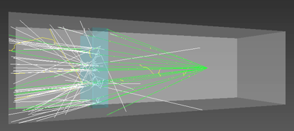

Se trata de un *universo* en forma de *cuboide* donde las partículas subatómicas son aceleradas (por los medios que sean) y son proyectadas con forma *cónica* contra un objetivo (un *target* o *fantoma*) de un material que podemos variar a nuestro antojo en composición, tamaño y posición. Nosotros no nos preocupamos sobre cómo esas partículas han cobrado esa energía, sino solamente por cómo interaccionan con la materia.

### Pregunta

**¿cómo se llama a este [tipo de haz](https://htmlpreview.github.io/?https://github.com/pammacdotnet/FFRepo/blob/master/geant4lab2021.html#search=%22pencil%20beam%22) de partículas?**

> Pencil beam